# Analysing a 10 year old Podcast

Nils Ratnaweera

2020-03-01T22:00:00+01:00

```r
library(tidyverse)
library(ggrepel)
library(scales)
library(tidytext)
library(lubridate)
theme_set(theme_minimal())
```

```r
head(folgenuebersicht)
```

```
## # A tibble: 6 x 6
##   title     date                duration item_link         rz_folge title_clean
##   <chr>     <dttm>                 <dbl> <chr>                <dbl> <chr>
## 1 RZ085 Er… 2020-03-07 23:00:00      115 https://raumzeit…       85 Erforschung…
## 2 RZ084 Be… 2020-02-06 23:00:00      123 https://raumzeit…       84 Besuch beim…
## 3 RZ083 Sp… 2020-01-16 23:00:00      164 https://raumzeit…       83 SpaceX
## 4 RZ082 Bo… 2019-12-19 23:00:00      127 https://raumzeit…       82 Bodenerkund…
## 5 Raumzeit… 2019-12-04 23:00:00        8 https://raumzeit…       NA Raumzeit 20…
## 6 RZ081 Hu… 2019-11-28 23:00:00      104 https://raumzeit…       81 Hubble-Welt…
```

### Number of Episodes per Year

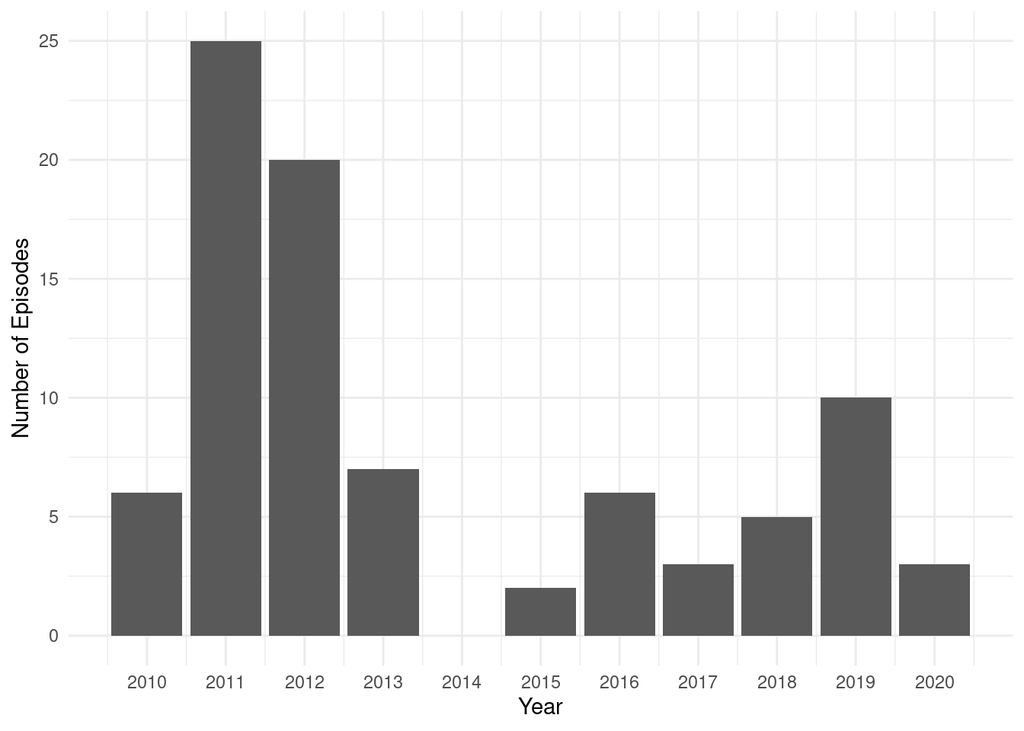

### Episode duration

What is remarkable about this podcast, is that Tim takes as much time as he needs with each guest, and doesn’t really keep an eye on the time. In his 87 podcasts to date he has spent over 145 hours speaking to his guests, which means an avarage of 100 minutes per episode.

The podcast’s duration can vary significantly, and I had wondered if there was some trend over time. Apparently, this does not seem to be the case, as shown in the following graph:

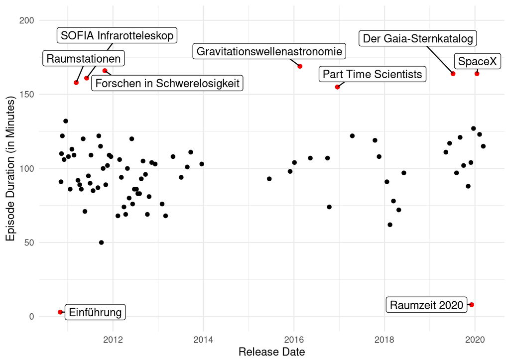

The two very short episodes are small housekeeping / information podcasts of which Tim has only produced two.

## Listener interaction

I was interested to know how intense the interaction was in regard to each podcast. I found two metrics with which this can be quantified:

- The replies posted on the [podcat’s website](https://raumzeit-podcast.de/)
- Twitter metrics (retweets, favourites, replies) of tweets Tim Pritlove posted after the appearance of a podcast with the user handle @raumzeit.

### Website replies

Again, using `rvest` I scraped the website to retrieve the replies for each podcast.

I was expecting some podcasts to have a high listener interaction and much discussion over time while others probabbly provoked little or no listener interaction. Old episodes have had a longer time period for such interaction, and so i wanted to visualize the intensity of the interaction (i.e. replies) in such a way, that this aspect becomes apparent.

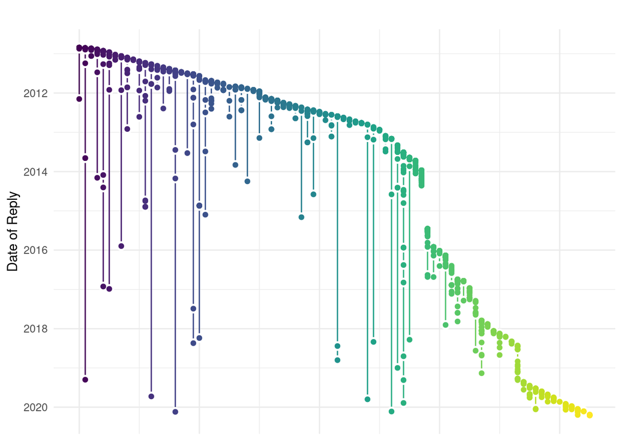

```r
folgen_replies_smry <- folgen_replies %>%
  group_by_at(1:6) %>%
  count(name = "Replies") %>%
  arrange(-Replies) %>%
  ungroup() %>%
  mutate(
    title_clean = fct_reorder(title_clean,Replies)
    )
```

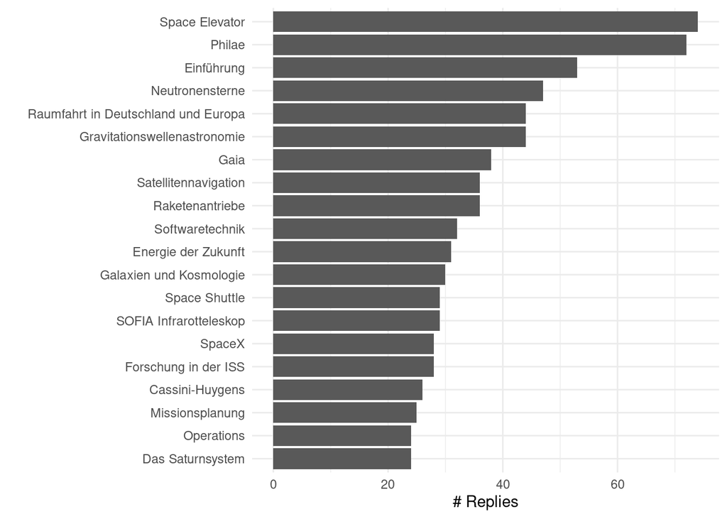

```r
folgen_replies_smry %>%
  head(20) %>%
  ggplot(aes(title_clean,Replies)) +
  geom_col() +
  ggplot2::coord_flip() +
  labs(y = "# Replies",x = "")
```

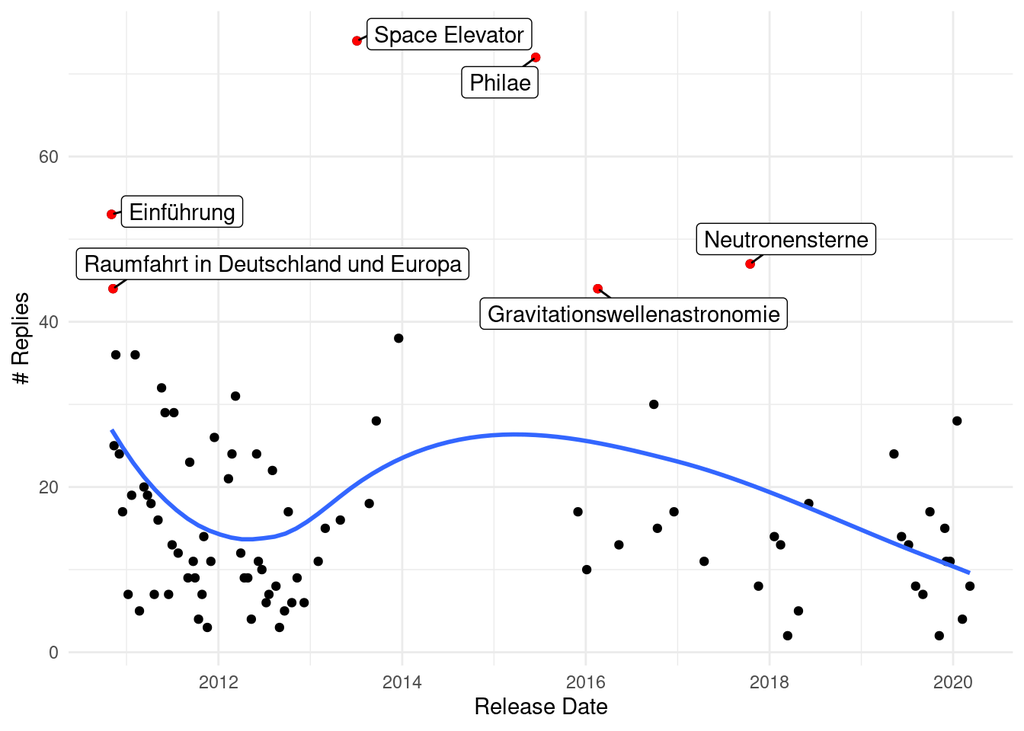

```r
folgen_replies_smry_filter <- filter(folgen_replies_smry, Replies > 40)

folgen_replies_smry %>%
  ggplot(aes(date,Replies, label = title_clean)) +
  geom_point() +
  geom_point(data = folgen_replies_smry_filter, colour = "red") +
  geom_label_repel(data = folgen_replies_smry_filter,min.segment.length = 0) +
  geom_smooth(method = "loess",se = FALSE) +
  labs(y = "# Replies",x = "Release Date")
```

```r
folgen_replies_unnest <- folgen_replies %>%
  unnest_tokens(word,comment)


stopwords <- tidytext::get_stopwords("de")

folgen_replies_unnest <- folgen_replies_unnest %>%
  anti_join(stopwords, by = "word")


# folgen_replies_unnest %>%
#   group_by(rz_folge,title_clean,word) %>%
#   count() %>%
#   filter(n > 10) %>%
#   bind_tf_idf(word,rz_folge,n) %>%
#   group_by(rz_folge) %>%
#   arrange(rz_folge,desc(tf_idf)) %>%
#   filter(n() == 1)
```

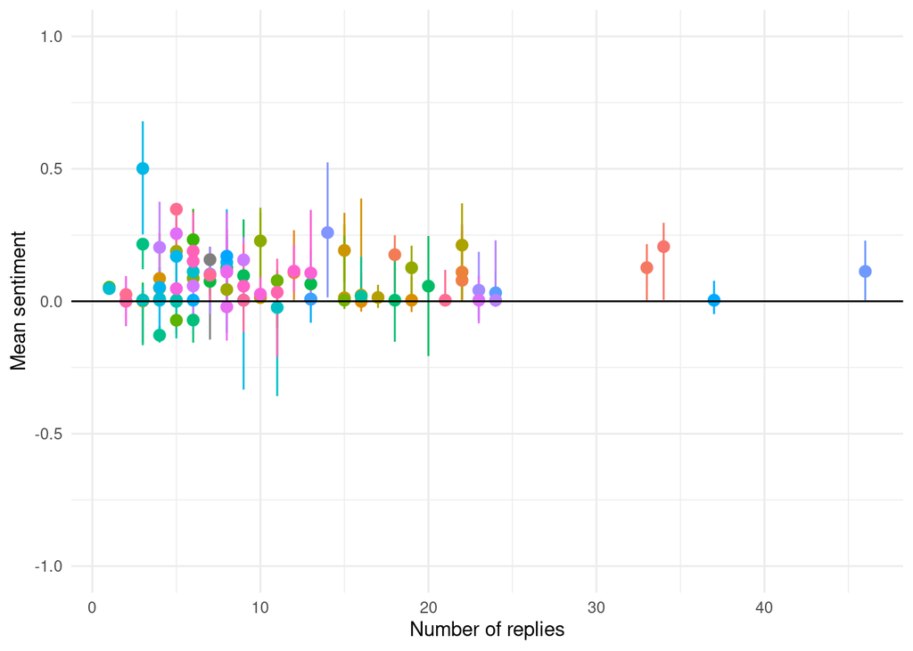

```r
sent <- c(
  # positive Wörter
  readLines("SentiWS_v2.0/SentiWS_v2.0_Positive.txt",
            encoding = "UTF-8"),
  # negative Wörter
  readLines("SentiWS_v2.0/SentiWS_v2.0_Negative.txt",
            encoding = "UTF-8")
) %>% lapply(function(x) {
  # Extrahieren der einzelnen Spalten
  res <- strsplit(x, "\t", fixed = TRUE)[[1]]
  return(data.frame(words = res[1], value = res[2],
                    stringsAsFactors = FALSE))
}) %>%
  bind_rows %>%
  mutate(words = gsub("\\|.*", "", words) %>% tolower,
         value = as.numeric(value)) %>%
  # manche Wörter kommen doppelt vor, hier nehmen wir den mittleren Wert
  group_by(words) %>% summarise(value = mean(value)) %>% ungroup
folgen_replies_unnest <- inner_join(folgen_replies_unnest,sent,by = c("word" = "words"))

folgen_reply_sent <- folgen_replies_unnest %>%
  group_by_at(1:7) %>%
  summarise(value = mean(value)) %>%
  group_by_at(1:6) %>%
  summarise(
    median = median(value),
    q25 = quantile(value,0.25),
    q75 = quantile(value,0.75),
    n = n(),
  )
ggplot(folgen_reply_sent, aes(n,median,ymin = q25,ymax = q75, colour = factor(rz_folge))) +
  # geom_point() +,
  geom_pointrange() +
  geom_hline(yintercept = 0) +
  labs(x = "Number of replies",y = "Mean sentiment") +
  lims(y = c(-1,1)) +
  theme(legend.position = "none")
```

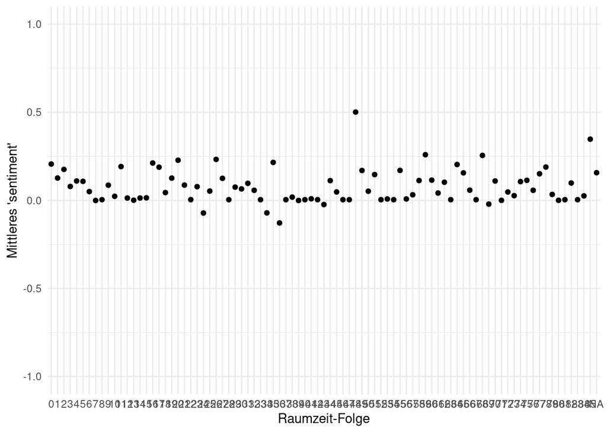

```r
folgen_reply_sent_fil <- folgen_reply_sent %>%
  filter(median > 0.3 | median< -0.1)

folgen_reply_sent %>%
  ggplot(aes(factor(rz_folge),median,label = title_clean)) +
  geom_point() +
  # geom_label_repel(data = folgen_reply_sent_fil,nudge_y = folgen_reply_sent_fil$value) +
  scale_y_continuous(limits = c(-1,1)) +
  labs(x = "Raumzeit-Folge",y = "Mittleres 'sentiment'")
```

```r
folgen_replies_unnest %>%
  group_by(word,value) %>%
  count() %>%
  arrange(desc(value))
```

```
## # A tibble: 743 x 3
## # Groups:   word, value [743]
##    word              value     n
##    <chr>             <dbl> <int>
##  1 gelungen          1         6
##  2 perfekt           0.730     6
##  3 lob               0.725     8
##  4 wunderbar         0.723     8
##  5 spannend          0.716    60
##  6 freude            0.650    11
##  7 mut               0.609     1
##  8 freundlich        0.602     1
##  9 hervorragend      0.589    11
## 10 abwechslungsreich 0.580     1
## # … with 733 more rows
```

```r
folgen_replies_unnest %>%
  filter(title_clean == "Mars Express") %>%
  pull(word)
```

```
## [1] "gelungen" "spannend" "sprung"   "super"
```

### Twitter Data

```r
raumtweets_folgen <- read_csv("raumtweets_folgen.csv")
```

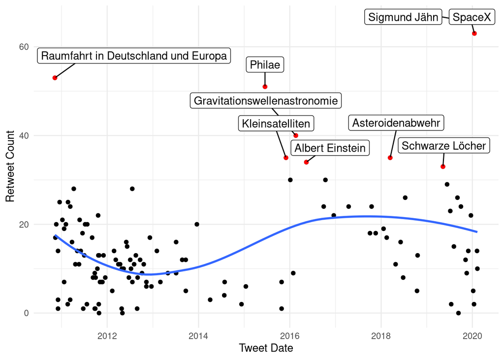

```r
raumtweets_folgen_filter <- filter(raumtweets_folgen,retweet_count>30)

ggplot(raumtweets_folgen, aes(created_at,retweet_count,label = title_clean)) +
  geom_point() +
  theme(legend.position = "none") +
  geom_point(data = raumtweets_folgen_filter,colour = "red") +
  geom_smooth(method = "loess",se = FALSE) +
  geom_label_repel(data = raumtweets_folgen_filter,nudge_x = 5,nudge_y = 5) +
  labs(x = "Tweet Date", y = "Retweet Count")
```

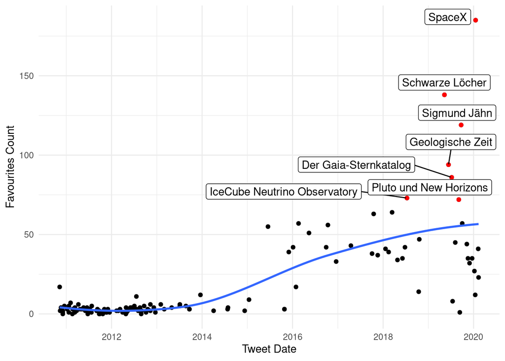

```r
raumtweets_folgen_filter <- filter(raumtweets_folgen,favorite_count>70)
ggplot(raumtweets_folgen, aes(created_at,favorite_count,label = title_clean)) +
  geom_point() +
  geom_point(data = raumtweets_folgen_filter, colour = "red") +
  geom_smooth(method = "loess",se = FALSE)  +
  geom_label_repel(data = raumtweets_folgen_filter, nudge_x = 5,nudge_y = 5) +
  labs(x = "Tweet Date", y = "Favourites Count")
```